# Assignment 4: MGCFA

2021-02-06

## MGCFA Assignment

Participants were given the Purpose in Life Questionnaire to examine if they endorsed finding purpose in their life. The psychometric properties of the PIL are under debate, especially the relationship between assessment types. You will test the following two-factor model for differences between a randomized questionnaire and a non-randomized questionnaire. Here are the proposed question loadings:

- Exciting life: 1 2 5 8 9 11 12 16 19
- Purposeful life: 3 4 6 7 10 13 17 18 20
- Note: Several questions are not used, be sure to drop them first.

You can learn more about the individual questions by using the following code (not the same data, but this dataset includes the actual questions in the documentation).

```r
library(learnSEM)
?meaningdata
```

## Reverse Coding

Reverse code the following questions: 2, 5, 7, 10, 17, 18, 19. Otherwise, assume the data is accurate. You can use `DF[ , COLUMN_NUMBERS] <- 8 - DF[ , COLUMN_NUMBERS]` to reverse code the items.

```r
library(lavaan)
```

```r
library(semPlot)

data = read.csv("assignment4_data.csv", stringsAsFactors = T)
data[, c(2,5,7,10,17,18,19)] = 8 - data[, c(2,5,7,10,17,18,19)]
```

## Missing values

- Include a table that shows the missing data by person (summary of missingness by participant).
- Exclude all people who are missing more than 5% for the variables you are interested in.
- Remember to use the data screening lecture to help you for this section of code.

```r
perMiss = function(x) {
  sum(is.na(x))/length(x) * 100
}
missing = apply(data[,-1], 1, perMiss)
table(missing)
```

```
## missing
##                0 4.34782608695652 8.69565217391304 13.0434782608696
##             1036              475               23                2
## 17.3913043478261 65.2173913043478
##                3                1
```

```r
noMiss = subset(data, missing <= 5)
summary(noMiss)
```

```
##            group           q1              q2              q3
##  Random Not   :738   Min.   :1.000   Min.   :1.000   Min.   :1.000
##  Random Random:773   1st Qu.:2.000   1st Qu.:2.000   1st Qu.:5.000
##                      Median :3.000   Median :3.000   Median :6.000
##                      Mean   :3.211   Mean   :3.227   Mean   :5.795
##                      3rd Qu.:4.000   3rd Qu.:4.000   3rd Qu.:7.000
##                      Max.   :7.000   Max.   :7.000   Max.   :7.000
##                      NA's   :1       NA's   :3
##        q4              q5              q6              q7
##  Min.   :1.000   Min.   :1.000   Min.   :1.000   Min.   :1.000
##  1st Qu.:1.000   1st Qu.:2.000   1st Qu.:1.000   1st Qu.:1.000
##  Median :2.000   Median :3.000   Median :2.000   Median :1.000
##  Mean   :2.315   Mean   :3.464   Mean   :2.578   Mean   :1.889
##  3rd Qu.:3.000   3rd Qu.:5.000   3rd Qu.:3.000   3rd Qu.:2.000
##  Max.   :7.000   Max.   :7.000   Max.   :7.000   Max.   :7.000
##  NA's   :1       NA's   :3       NA's   :2       NA's   :1
##        q8              q9             q10             q11
##  Min.   :1.000   Min.   :1.000   Min.   :1.000   Min.   :1.000
##  1st Qu.:5.000   1st Qu.:2.000   1st Qu.:2.000   1st Qu.:4.000
##  Median :5.000   Median :3.000   Median :2.000   Median :6.000
##  Mean   :4.995   Mean   :2.619   Mean   :2.779   Mean   :5.248
##  3rd Qu.:6.000   3rd Qu.:3.000   3rd Qu.:4.000   3rd Qu.:7.000
##  Max.   :7.000   Max.   :7.000   Max.   :7.000   Max.   :7.000
##  NA's   :2       NA's   :2       NA's   :3       NA's   :5
##       q12             q13            q14             q15            q16
##  Min.   :1.000   Min.   :1.00   Min.   :1.000   Min.   :1.00   Min.   :1.000
##  1st Qu.:4.000   1st Qu.:5.00   1st Qu.:1.000   1st Qu.:2.00   1st Qu.:1.000
##  Median :5.000   Median :6.00   Median :2.000   Median :4.00   Median :2.000
##  Mean   :4.532   Mean   :5.78   Mean   :2.665   Mean   :4.01   Mean   :2.691
##  3rd Qu.:6.000   3rd Qu.:7.00   3rd Qu.:4.000   3rd Qu.:6.00   3rd Qu.:4.000
##  Max.   :7.000   Max.   :7.00   Max.   :7.000   Max.   :7.00   Max.   :7.000
##  NA's   :3       NA's   :1      NA's   :1       NA's   :434    NA's   :1
##       q17             q18             q19             q20
##  Min.   :1.000   Min.   :1.000   Min.   :1.000   Min.   :1.000
##  1st Qu.:4.000   1st Qu.:4.000   1st Qu.:2.000   1st Qu.:5.000
##  Median :6.000   Median :6.000   Median :3.000   Median :5.000
##  Mean   :5.421   Mean   :5.343   Mean   :3.134   Mean   :5.309
##  3rd Qu.:7.000   3rd Qu.:7.000   3rd Qu.:4.000   3rd Qu.:6.000
##  Max.   :7.000   Max.   :7.000   Max.   :7.000   Max.   :7.000
##  NA's   :8       NA's   :2       NA's   :1       NA's   :1
##      total1          total2          total3
##  Min.   : 91.0   Min.   : 95.0   Min.   : 96
##  1st Qu.:101.0   1st Qu.:104.0   1st Qu.:106
##  Median :104.0   Median :106.0   Median :108
##  Mean   :103.5   Mean   :106.4   Mean   :108
##  3rd Qu.:106.0   3rd Qu.:109.0   3rd Qu.:110
##  Max.   :116.0   Max.   :119.0   Max.   :120
##
```

- Include the percent/proportion of data missing by column.
- Impute the missing values with mice for participants and columns with less than 5% of missing data.

```r
colMissing = apply(noMiss[,-1], 2, perMiss)
table(colMissing)
```

```
## colMissing
##                  0 0.0661813368630046  0.132362673726009  0.198544010589014
##                  4                  8                  4                  4
##  0.330906684315023  0.529450694904037    28.722700198544
##                  1                  1                  1
```

```r
colMis = subset(noMiss, missing <= 5)
```

## CFA Models

In the next section, you will include the `overall.model`, the `cfa()`, and `summary()` for each step of the multigroup analysis. Use the class assignment to create these steps and a table of your results. You will use the `group` variable as your muligroup test. The random random group saw many meaning scales in a randomized order and randomized display of each item, while the random not group saw many randomized scales with a set order of each item within the scale.

## Overall Model

```r
data = colMis
overall.model = '
QQ =~ q1 + q2 + q3 + q4 + q5 + q6 + q7 + q8 + q9 + q10 + q11 + q12 + q13 + q14 + q15 + q16 + q17 + q18 + q19 + q20
'
overall.fit = cfa(model = overall.model, data = data, meanstructure = T)
summary(overall.fit, standardized = T, rsquare = T, fit.measure = T)
```

```
## lavaan 0.6-7 ended normally after 31 iterations
##
##   Estimator                                         ML
##   Optimization method                           NLMINB
##   Number of free parameters                         60
##
##                                                   Used       Total
##   Number of observations                          1025        1511
##
## Model Test User Model:
##
##   Test statistic                              1358.223
##   Degrees of freedom                               170
##   P-value (Chi-square)                           0.000
##
## Model Test Baseline Model:
##
##   Test statistic                              9389.315
##   Degrees of freedom                               190
##   P-value                                        0.000
##
## User Model versus Baseline Model:
##
##   Comparative Fit Index (CFI)                    0.871
##   Tucker-Lewis Index (TLI)                       0.856
##
## Loglikelihood and Information Criteria:
##
##   Loglikelihood user model (H0)             -32723.073
##   Loglikelihood unrestricted model (H1)     -32043.961
##
##   Akaike (AIC)                               65566.145
##   Bayesian (BIC)                             65862.092
##   Sample-size adjusted Bayesian (BIC)        65671.526
##
## Root Mean Square Error of Approximation:
##
##   RMSEA                                          0.083
##   90 Percent confidence interval - lower         0.079
##   90 Percent confidence interval - upper         0.087
```

[output cut: 91 more lines]

```
##     q6                0.456
##     q7                0.159
##     q8                0.358
##     q9                0.634
##     q10               0.553
##     q11               0.593
##     q12               0.411
##     q13               0.138
##     q14               0.207
##     q15               0.035
##     q16               0.302
##     q17               0.442
##     q18               0.214
##     q19               0.476
##     q20               0.600
```

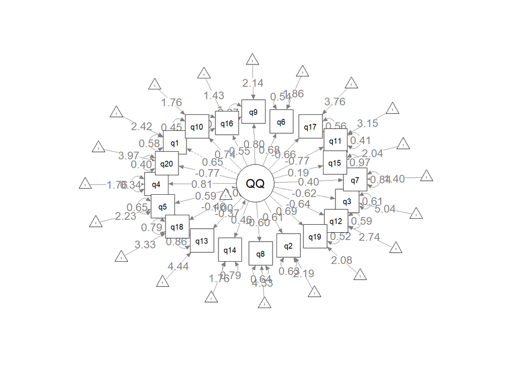

```r
semPaths(overall.fit, whatLabels = "std", layout = "spring", edge.label.cex = 1)
```

```r
library(knitr)
table_fit <- matrix(NA, nrow = 8, ncol = 6)
colnames(table_fit) = c("Model", "X2", "df", "CFI", "RMSEA", "SRMR")
table_fit[1, ] <- c("Overall Model", round(fitmeasures(overall.fit,
                                                 c("chisq", "df", "cfi",
                                                   "rmsea", "srmr")),3))
kable(table_fit)
```

| Model | X2 | df | CFI | RMSEA | SRMR |
| --- | --- | --- | --- | --- | --- |
| Overall Model | 1358.223 | 170 | 0.871 | 0.083 | 0.051 |
| NA | NA | NA | NA | NA | NA |
| NA | NA | NA | NA | NA | NA |
| NA | NA | NA | NA | NA | NA |
| NA | NA | NA | NA | NA | NA |
| NA | NA | NA | NA | NA | NA |
| NA | NA | NA | NA | NA | NA |
| NA | NA | NA | NA | NA | NA |

## Random Random

```r
random.random.fit = cfa(model = overall.model, data = data[data$group == "Random Random",], meanstructure = T)
summary(random.random.fit, standardized = T, rsquare = T, fit.measure = T)
```

```
## lavaan 0.6-7 ended normally after 34 iterations
##
##   Estimator                                         ML
##   Optimization method                           NLMINB
##   Number of free parameters                         60
##
##                                                   Used       Total
##   Number of observations                           354         782
##
## Model Test User Model:
##
##   Test statistic                               817.810
##   Degrees of freedom                               170
##   P-value (Chi-square)                           0.000
##
## Model Test Baseline Model:
##
##   Test statistic                              3270.491
##   Degrees of freedom                               190
##   P-value                                        0.000
##
## User Model versus Baseline Model:
##
##   Comparative Fit Index (CFI)                    0.790
##   Tucker-Lewis Index (TLI)                       0.765
##
## Loglikelihood and Information Criteria:
##
##   Loglikelihood user model (H0)             -11465.913
##   Loglikelihood unrestricted model (H1)     -11057.008
##
##   Akaike (AIC)                               23051.826
##   Bayesian (BIC)                             23283.983
##   Sample-size adjusted Bayesian (BIC)        23093.638
##
## Root Mean Square Error of Approximation:
##
##   RMSEA                                          0.104
##   90 Percent confidence interval - lower         0.097
##   90 Percent confidence interval - upper         0.111
```

[output cut: 91 more lines]

```
##     q6                0.444
##     q7                0.130
##     q8                0.381
##     q9                0.637
##     q10               0.454
##     q11               0.519
##     q12               0.360
##     q13               0.118
##     q14               0.239
##     q15               0.025
##     q16               0.330
##     q17               0.353
##     q18               0.219
##     q19               0.414
##     q20               0.495
```

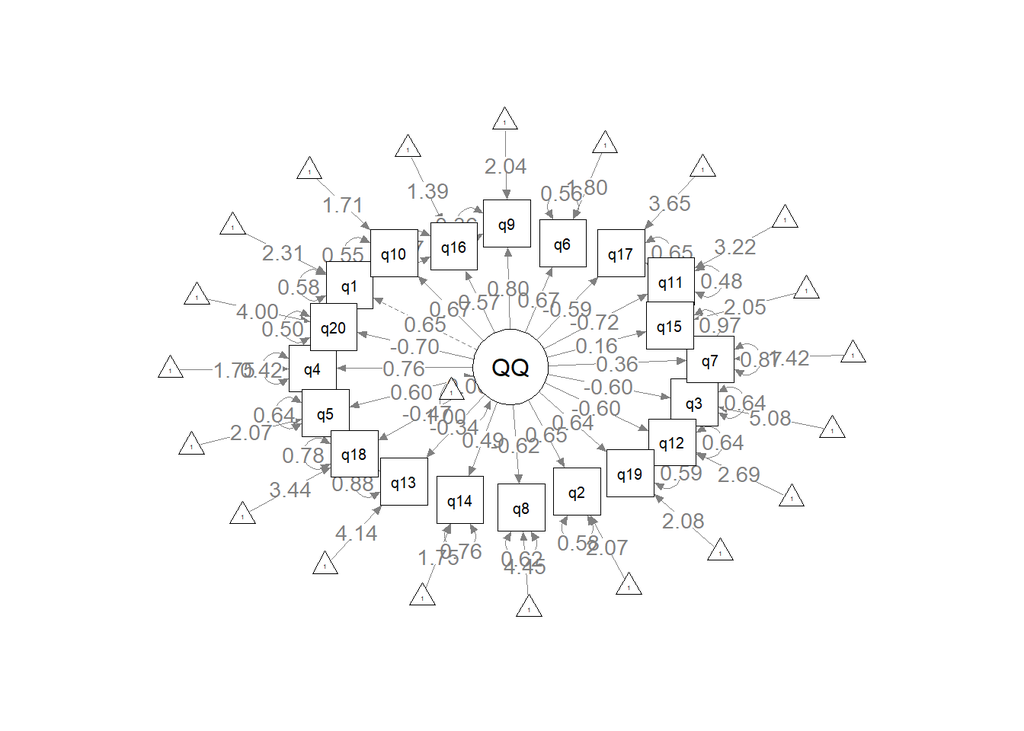

```r
semPaths(random.random.fit, whatLabels = "std", layout = "spring", edge.label.cex = 1)
```

```r
table_fit[2, ] <- c("Random Random Model", round(fitmeasures(random.random.fit,
                                                 c("chisq", "df", "cfi",
                                                   "rmsea", "srmr")),3))
kable(table_fit)
```

| Model | X2 | df | CFI | RMSEA | SRMR |
| --- | --- | --- | --- | --- | --- |
| Overall Model | 1358.223 | 170 | 0.871 | 0.083 | 0.051 |
| Random Random Model | 817.81 | 170 | 0.79 | 0.104 | 0.074 |
| NA | NA | NA | NA | NA | NA |
| NA | NA | NA | NA | NA | NA |
| NA | NA | NA | NA | NA | NA |
| NA | NA | NA | NA | NA | NA |
| NA | NA | NA | NA | NA | NA |
| NA | NA | NA | NA | NA | NA |

## Random Not

```r
random.not.fit = cfa(model = overall.model, data = data[data$group == "Random Not",], meanstructure = T)
summary(random.not.fit, standardized = T, rsquare = T, fit.measure = T)
```

```
## lavaan 0.6-7 ended normally after 33 iterations
##
##   Estimator                                         ML
##   Optimization method                           NLMINB
##   Number of free parameters                         60
##
##                                                   Used       Total
##   Number of observations                           671         758
##
## Model Test User Model:
##
##   Test statistic                               854.261
##   Degrees of freedom                               170
##   P-value (Chi-square)                           0.000
##
## Model Test Baseline Model:
##
##   Test statistic                              6479.911
##   Degrees of freedom                               190
##   P-value                                        0.000
##
## User Model versus Baseline Model:
##
##   Comparative Fit Index (CFI)                    0.891
##   Tucker-Lewis Index (TLI)                       0.878
##
## Loglikelihood and Information Criteria:
##
##   Loglikelihood user model (H0)             -21184.518
##   Loglikelihood unrestricted model (H1)     -20757.387
##
##   Akaike (AIC)                               42489.036
##   Bayesian (BIC)                             42759.562
##   Sample-size adjusted Bayesian (BIC)        42569.058
##
## Root Mean Square Error of Approximation:
##
##   RMSEA                                          0.077
##   90 Percent confidence interval - lower         0.072
##   90 Percent confidence interval - upper         0.083
```

[output cut: 91 more lines]

```
##     q6                0.458
##     q7                0.172
##     q8                0.346
##     q9                0.630
##     q10               0.600
##     q11               0.632
##     q12               0.441
##     q13               0.150
##     q14               0.192
##     q15               0.045
##     q16               0.293
##     q17               0.496
##     q18               0.214
##     q19               0.519
##     q20               0.656
```

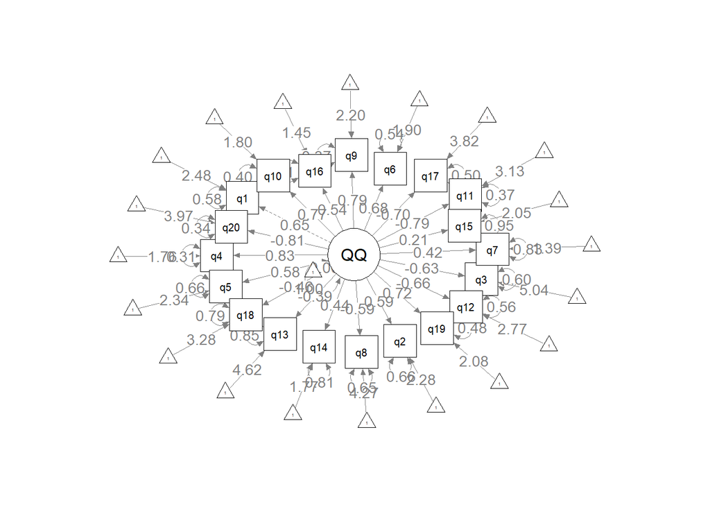

```r
semPaths(random.not.fit, whatLabels = "std", layout = "spring", edge.label.cex = 1)
```

```r
table_fit[3, ] <- c("Random Not Model", round(fitmeasures(random.not.fit,
                                                 c("chisq", "df", "cfi",
                                                   "rmsea", "srmr")),3))
kable(table_fit)
```

| Model | X2 | df | CFI | RMSEA | SRMR |
| --- | --- | --- | --- | --- | --- |
| Overall Model | 1358.223 | 170 | 0.871 | 0.083 | 0.051 |
| Random Random Model | 817.81 | 170 | 0.79 | 0.104 | 0.074 |
| Random Not Model | 854.261 | 170 | 0.891 | 0.077 | 0.048 |
| NA | NA | NA | NA | NA | NA |
| NA | NA | NA | NA | NA | NA |
| NA | NA | NA | NA | NA | NA |
| NA | NA | NA | NA | NA | NA |
| NA | NA | NA | NA | NA | NA |

## Configural

```r
configural.fit = cfa(model = overall.model, data = data, meanstructure = T, group = "group")
summary(configural.fit, standardized = T, rsquare = T, fit.measure = T)
```

```
## lavaan 0.6-7 ended normally after 60 iterations
##
##   Estimator                                         ML
##   Optimization method                           NLMINB
##   Number of free parameters                        120
##
##   Number of observations per group:               Used       Total
##     Random Not                                     671         729
##     Random Random                                  354         753
##
## Model Test User Model:
##
##   Test statistic                              1672.071
##   Degrees of freedom                               340
##   P-value (Chi-square)                           0.000
##   Test statistic for each group:
##     Random Not                                 854.261
##     Random Random                              817.810
##
## Model Test Baseline Model:
##
##   Test statistic                              9750.402
##   Degrees of freedom                               380
##   P-value                                        0.000
##
## User Model versus Baseline Model:
##
##   Comparative Fit Index (CFI)                    0.858
##   Tucker-Lewis Index (TLI)                       0.841
##
## Loglikelihood and Information Criteria:
##
##   Loglikelihood user model (H0)             -32650.431
##   Loglikelihood unrestricted model (H1)     -31814.395
##
##   Akaike (AIC)                               65540.862
##   Bayesian (BIC)                             66132.756
##   Sample-size adjusted Bayesian (BIC)        65751.623
##
## Root Mean Square Error of Approximation:
```

[output cut: 196 more lines]

```
##     q6                0.444
##     q7                0.130
##     q8                0.381
##     q9                0.637
##     q10               0.454
##     q11               0.519
##     q12               0.360
##     q13               0.118
##     q14               0.239
##     q15               0.025
##     q16               0.330
##     q17               0.353
##     q18               0.219
##     q19               0.414
##     q20               0.495
```

```r
table_fit[4, ] <- c("Configural Model", round(fitmeasures(configural.fit,
                                                 c("chisq", "df", "cfi",
                                                   "rmsea", "srmr")),3))
kable(table_fit)
```

| Model | X2 | df | CFI | RMSEA | SRMR |
| --- | --- | --- | --- | --- | --- |
| Overall Model | 1358.223 | 170 | 0.871 | 0.083 | 0.051 |
| Random Random Model | 817.81 | 170 | 0.79 | 0.104 | 0.074 |
| Random Not Model | 854.261 | 170 | 0.891 | 0.077 | 0.048 |
| Configural Model | 1672.071 | 340 | 0.858 | 0.087 | 0.057 |
| NA | NA | NA | NA | NA | NA |
| NA | NA | NA | NA | NA | NA |
| NA | NA | NA | NA | NA | NA |
| NA | NA | NA | NA | NA | NA |

## Metric

```r
metric.fit = cfa(model = overall.model, data = data, meanstructure = T, group = "group", group.equal = c("loadings"))
summary(metric.fit, standardized = T, rsquare = T, fit.measure = T)
```

```
## lavaan 0.6-7 ended normally after 50 iterations
##
##   Estimator                                         ML
##   Optimization method                           NLMINB
##   Number of free parameters                        120
##   Number of equality constraints                    19
##
##   Number of observations per group:               Used       Total
##     Random Not                                     671         729
##     Random Random                                  354         753
##
## Model Test User Model:
##
##   Test statistic                              1690.528
##   Degrees of freedom                               359
##   P-value (Chi-square)                           0.000
##   Test statistic for each group:
##     Random Not                                 859.783
##     Random Random                              830.746
##
## Model Test Baseline Model:
##
##   Test statistic                              9750.402
##   Degrees of freedom                               380
##   P-value                                        0.000
##
## User Model versus Baseline Model:
##
##   Comparative Fit Index (CFI)                    0.858
##   Tucker-Lewis Index (TLI)                       0.850
##
## Loglikelihood and Information Criteria:
##
##   Loglikelihood user model (H0)             -32659.659
##   Loglikelihood unrestricted model (H1)     -31814.395
##
##   Akaike (AIC)                               65521.319
##   Bayesian (BIC)                             66019.496
##   Sample-size adjusted Bayesian (BIC)        65698.710
##
```

[output cut: 197 more lines]

```
##     q6                0.443
##     q7                0.154
##     q8                0.356
##     q9                0.608
##     q10               0.496
##     q11               0.533
##     q12               0.359
##     q13               0.110
##     q14               0.212
##     q15               0.031
##     q16               0.293
##     q17               0.376
##     q18               0.210
##     q19               0.437
##     q20               0.516
```

```r
table_fit[5, ] <- c("Metric Model", round(fitmeasures(metric.fit,
                                                 c("chisq", "df", "cfi",
                                                   "rmsea", "srmr")),3))
kable(table_fit)
```

| Model | X2 | df | CFI | RMSEA | SRMR |
| --- | --- | --- | --- | --- | --- |
| Overall Model | 1358.223 | 170 | 0.871 | 0.083 | 0.051 |
| Random Random Model | 817.81 | 170 | 0.79 | 0.104 | 0.074 |
| Random Not Model | 854.261 | 170 | 0.891 | 0.077 | 0.048 |
| Configural Model | 1672.071 | 340 | 0.858 | 0.087 | 0.057 |
| Metric Model | 1690.528 | 359 | 0.858 | 0.085 | 0.06 |
| NA | NA | NA | NA | NA | NA |
| NA | NA | NA | NA | NA | NA |
| NA | NA | NA | NA | NA | NA |

## Scalar

```r
scalar.fit = cfa(model = overall.model, data = data, meanstructure = T, group = "group", group.equal = c("loadings", "intercepts"))
summary(scalar.fit, standardized = T, rsquare = T, fit.measure = T)
```

```
## lavaan 0.6-7 ended normally after 78 iterations
##
##   Estimator                                         ML
##   Optimization method                           NLMINB
##   Number of free parameters                        121
##   Number of equality constraints                    39
##
##   Number of observations per group:               Used       Total
##     Random Not                                     671         729
##     Random Random                                  354         753
##
## Model Test User Model:
##
##   Test statistic                              1729.179
##   Degrees of freedom                               378
##   P-value (Chi-square)                           0.000
##   Test statistic for each group:
##     Random Not                                 873.431
##     Random Random                              855.749
##
## Model Test Baseline Model:
##
##   Test statistic                              9750.402
##   Degrees of freedom                               380
##   P-value                                        0.000
##
## User Model versus Baseline Model:
##
##   Comparative Fit Index (CFI)                    0.856
##   Tucker-Lewis Index (TLI)                       0.855
##
## Loglikelihood and Information Criteria:
##
##   Loglikelihood user model (H0)             -32678.985
##   Loglikelihood unrestricted model (H1)     -31814.395
##
##   Akaike (AIC)                               65521.970
##   Bayesian (BIC)                             65926.430
##   Sample-size adjusted Bayesian (BIC)        65665.990
##
```

[output cut: 197 more lines]

```
##     q6                0.444
##     q7                0.154
##     q8                0.354
##     q9                0.608
##     q10               0.496
##     q11               0.533
##     q12               0.356
##     q13               0.110
##     q14               0.213
##     q15               0.028
##     q16               0.292
##     q17               0.372
##     q18               0.209
##     q19               0.433
##     q20               0.516
```

```r
table_fit[6, ] <- c("Scalar Model", round(fitmeasures(scalar.fit,
                                                 c("chisq", "df", "cfi",
                                                   "rmsea", "srmr")),3))
kable(table_fit)
```

| Model | X2 | df | CFI | RMSEA | SRMR |
| --- | --- | --- | --- | --- | --- |
| Overall Model | 1358.223 | 170 | 0.871 | 0.083 | 0.051 |
| Random Random Model | 817.81 | 170 | 0.79 | 0.104 | 0.074 |
| Random Not Model | 854.261 | 170 | 0.891 | 0.077 | 0.048 |
| Configural Model | 1672.071 | 340 | 0.858 | 0.087 | 0.057 |
| Metric Model | 1690.528 | 359 | 0.858 | 0.085 | 0.06 |
| Scalar Model | 1729.179 | 378 | 0.856 | 0.084 | 0.061 |
| NA | NA | NA | NA | NA | NA |
| NA | NA | NA | NA | NA | NA |

## Strict

```r
strict.fit = cfa(model = overall.model, data = data, meanstructure = T, group = "group", group.equal = c("loadings", "intercepts", "residuals"))
summary(strict.fit, standardized = T, rsquare = T, fit.measure = T)
```

```
## lavaan 0.6-7 ended normally after 66 iterations
##
##   Estimator                                         ML
##   Optimization method                           NLMINB
##   Number of free parameters                        121
##   Number of equality constraints                    59
##
##   Number of observations per group:               Used       Total
##     Random Not                                     671         729
##     Random Random                                  354         753
##
## Model Test User Model:
##
##   Test statistic                              1810.083
##   Degrees of freedom                               398
##   P-value (Chi-square)                           0.000
##   Test statistic for each group:
##     Random Not                                 906.442
##     Random Random                              903.641
##
## Model Test Baseline Model:
##
##   Test statistic                              9750.402
##   Degrees of freedom                               380
##   P-value                                        0.000
##
## User Model versus Baseline Model:
##
##   Comparative Fit Index (CFI)                    0.849
##   Tucker-Lewis Index (TLI)                       0.856
##
## Loglikelihood and Information Criteria:
##
##   Loglikelihood user model (H0)             -32719.437
##   Loglikelihood unrestricted model (H1)     -31814.395
##
##   Akaike (AIC)                               65562.873
##   Bayesian (BIC)                             65868.685
##   Sample-size adjusted Bayesian (BIC)        65671.767
##
```

[output cut: 197 more lines]

```
##     q6                0.436
##     q7                0.148
##     q8                0.339
##     q9                0.615
##     q10               0.533
##     q11               0.573
##     q12               0.391
##     q13               0.129
##     q14               0.194
##     q15               0.032
##     q16               0.285
##     q17               0.421
##     q18               0.201
##     q19               0.455
##     q20               0.580
```

```r
table_fit[7, ] <- c("Strict Model", round(fitmeasures(strict.fit,
                                                 c("chisq", "df", "cfi",
                                                   "rmsea", "srmr")),3))
kable(table_fit)
```

| Model | X2 | df | CFI | RMSEA | SRMR |
| --- | --- | --- | --- | --- | --- |
| Overall Model | 1358.223 | 170 | 0.871 | 0.083 | 0.051 |
| Random Random Model | 817.81 | 170 | 0.79 | 0.104 | 0.074 |
| Random Not Model | 854.261 | 170 | 0.891 | 0.077 | 0.048 |
| Configural Model | 1672.071 | 340 | 0.858 | 0.087 | 0.057 |
| Metric Model | 1690.528 | 359 | 0.858 | 0.085 | 0.06 |
| Scalar Model | 1729.179 | 378 | 0.856 | 0.084 | 0.061 |
| Strict Model | 1810.083 | 398 | 0.849 | 0.083 | 0.062 |
| NA | NA | NA | NA | NA | NA |

QUESTION: In looking at this complete table, do you have complete invariance or does it show a drop in fit? If you see a drop in fit, where does the fit change? ANSWER: No, they are in acceptable range.

## Partial Invariance

If you answered that the model shows a drop in fit, find the items that would create a partially invariant model. Use the loop code from class to calculate each CFI and add the strongest parameter. Update your table to include the new model fit. If you saw invariant fit above, you can skip this section.

```r
partial_syntax = paste(colnames(data)[2:21], "~~", colnames(data)[2:21])
CFI_list  <- 1:length(partial_syntax)
names(CFI_list) <- partial_syntax

for (i in 1:length(partial_syntax)){
  temp <- cfa(model = overall.model,
              data = data,
              meanstructure = TRUE,
              group = "group",
              group.equal = c("loadings", "intercepts", "residuals"),
              group.partial = partial_syntax[i])
  CFI_list[i] <- fitmeasures(temp, "cfi")
}
```

[output not shown]

```r
which.max(CFI_list)
```

```
## q20 ~~ q20
##         20
```

```r
partial.fit <- cfa(model = overall.model, data = data, meanstructure = T, group = "group", group.equal = c("loadings", "intercepts", "residuals"), group.partial = c("q20 ~~ q20"))
summary(partial.fit, standardized = T, rsquare = T, fit.measure = T)
```

```
## lavaan 0.6-7 ended normally after 67 iterations
##
##   Estimator                                         ML
##   Optimization method                           NLMINB
##   Number of free parameters                        121
##   Number of equality constraints                    58
##
##   Number of observations per group:               Used       Total
##     Random Not                                     671         729
##     Random Random                                  354         753
##
## Model Test User Model:
##
##   Test statistic                              1791.416
##   Degrees of freedom                               397
##   P-value (Chi-square)                           0.000
##   Test statistic for each group:
##     Random Not                                 898.229
##     Random Random                              893.187
##
## Model Test Baseline Model:
##
##   Test statistic                              9750.402
##   Degrees of freedom                               380
##   P-value                                        0.000
##
## User Model versus Baseline Model:
##
##   Comparative Fit Index (CFI)                    0.851
##   Tucker-Lewis Index (TLI)                       0.858
##
## Loglikelihood and Information Criteria:
##
##   Loglikelihood user model (H0)             -32710.103
##   Loglikelihood unrestricted model (H1)     -31814.395
##
##   Akaike (AIC)                               65546.206
##   Bayesian (BIC)                             65856.950
##   Sample-size adjusted Bayesian (BIC)        65656.856
##
```

[output cut: 197 more lines]

```
##     q6                0.435
##     q7                0.148
##     q8                0.338
##     q9                0.613
##     q10               0.532
##     q11               0.573
##     q12               0.391
##     q13               0.129
##     q14               0.195
##     q15               0.031
##     q16               0.286
##     q17               0.421
##     q18               0.201
##     q19               0.457
##     q20               0.517
```

```r
table_fit[8, ] <- c("Partial Model", round(fitmeasures(partial.fit,
                                                 c("chisq", "df", "cfi",
                                                   "rmsea", "srmr")),3))
kable(table_fit)
```

| Model | X2 | df | CFI | RMSEA | SRMR |
| --- | --- | --- | --- | --- | --- |
| Overall Model | 1358.223 | 170 | 0.871 | 0.083 | 0.051 |
| Random Random Model | 817.81 | 170 | 0.79 | 0.104 | 0.074 |
| Random Not Model | 854.261 | 170 | 0.891 | 0.077 | 0.048 |
| Configural Model | 1672.071 | 340 | 0.858 | 0.087 | 0.057 |
| Metric Model | 1690.528 | 359 | 0.858 | 0.085 | 0.06 |
| Scalar Model | 1729.179 | 378 | 0.856 | 0.084 | 0.061 |
| Strict Model | 1810.083 | 398 | 0.849 | 0.083 | 0.062 |
| Partial Model | 1791.416 | 397 | 0.851 | 0.083 | 0.062 |

QUESTION: Does the addition of these parameter(s) bring the model up to a partially invariant fit? ANSWER: Yes, it does. RMSEA is also convering

## Latent Means

Using `lavPredict()` on the latent variables (i.e., no `ov`), calculate the latent means for our two groups. Using the `MOTE` library, calculate if there is a difference on the latent means.

```r
library(MOTE)
predicted_scores = lavPredict(partial.fit, type = "ov")
table(data$group)
```

```
##
##    Random Not Random Random
##           729           753
```

```r
predicted_scores <- as.data.frame(do.call(rbind, predicted_scores))
predicted_scores$group <- c(rep("Random Not", 671), rep("Random Random", 354))
predicted_scores$sum <- apply(predicted_scores[ , 1:20], 1, sum)
head(predicted_scores)
```

```
##         q1       q2       q3       q4       q5       q6       q7       q8
## 1 5.908772 6.076882 3.523666 5.704979 6.354029 5.587838 3.582623 2.822368
## 2 3.854998 3.915075 5.248681 3.134262 4.155247 3.322858 2.296979 4.494095
## 3 5.370051 5.509823 3.976151 5.030660 5.777272 4.993716 3.245388 3.260875
## 4 4.479502 4.572430 4.724145 3.915957 4.823845 4.011585 2.687913 3.985762
## 5 4.198381 4.276521 4.960265 3.564076 4.522875 3.701554 2.511934 4.214589
## 6 5.106584 5.232498 4.197443 4.700878 5.495203 4.703155 3.080461 3.475331
##         q9      q10      q11      q12      q13      q14      q15      q16
## 1 5.706421 6.493792 1.168237 1.154384 4.231452 4.862950 5.167491 6.018909
## 2 3.367200 3.679757 4.233629 3.701586 5.395687 3.201228 4.293498 3.510379
## 3 5.092825 5.755648 1.972313 1.822535 4.536840 4.427067 4.938235 5.360902
## 4 4.078502 4.535439 3.301515 2.927042 5.041670 3.706518 4.559259 4.273164
## 5 3.758308 4.150253 3.721107 3.275704 5.201032 3.479061 4.439626 3.929795
## 6 4.792740 5.394653 2.365554 2.149300 4.686193 4.213894 4.826116 5.039097
##        q17      q18      q19      q20      group      sum
## 1 2.371533 2.982025 6.346753 1.993016 Random Not 88.05812
## 2 4.670953 4.770675 3.881020 4.482085 Random Not 79.60989
## 3 2.974689 3.451202 5.699972 2.645918 Random Not 85.84208
## 4 3.971754 4.226788 4.630792 3.725217 Random Not 82.17880
## 5 4.286499 4.471619 4.293281 4.065922 Random Not 81.02240
## 6 3.269668 3.680657 5.383658 2.965226 Random Not 84.75831
```

```r
tapply(predicted_scores$sum, predicted_scores$group, mean)
```

```
##    Random Not Random Random
##      77.09521      76.51690
```